# Who is retweeting tweets about '@CSOIreland'?

Interesting question….this is how we find the answer.

First you need to be able to identify yourself as a registered twitter user to twitter. More details on that are on the link below.

http://thinktostart.com/twitter-authentification-with-r/

After you have done that you can use the code below. This code is valid in June 2015, however as R updates quite frequently code instructions and functions can become “deprecated”. The term deprecated means that the code you have entered has been tweaked and no longer works with your version of R, is no longer used or has been renamed. The best thing to do in these cases is to copy and paste the error message you get when you ran the code into a search engine and investigate what went wrong. This is why it takes a little experience and know how to be comfortable with using R and troubleshooting issues such as this. It is quite unforgiving if a piece of code is even a slightest bit off. Who’d have a thought a comma can be followed by an argument ? That said, R is improving all the time and eventually this statement, like some of the code below perhaps, will be outdated and irrelevant.

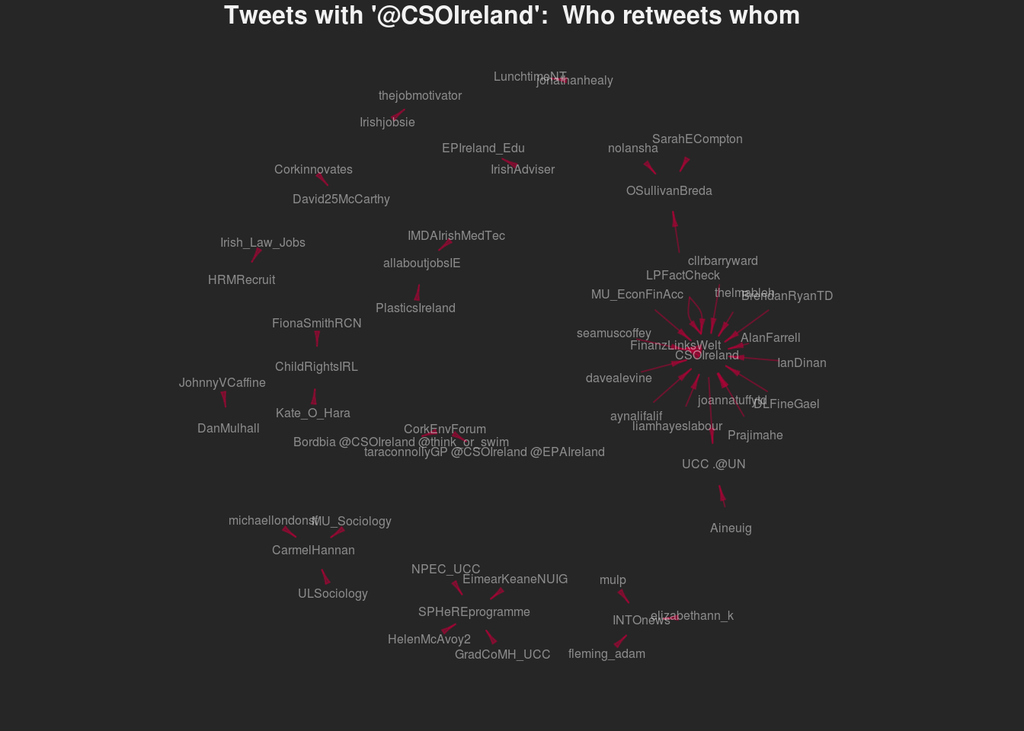

```r
library("twitteR")
library("igraph")
library("stringr")
#Harvest tweets about "CSOIreland"
# tweets in english containing "CSOIreland"
dm_tweets = searchTwitter("@CSOIreland", n=1000, lang="en")
# get text
dm_txt = sapply(dm_tweets, function(x) x$getText())


# regular expressions to find retweets
grep("(RT|via)((?:\\b\\W*@\\w+)+)", dm_tweets,
     ignore.case=TRUE, value=TRUE)

# which tweets are retweets
rt_patterns = grep("(RT|via)((?:\\b\\W*@\\w+)+)",
                   dm_txt, ignore.case=TRUE)

# show retweets (these are the ones we want to focus on)
#dm_txt[rt_patterns]


#Collect who retweeted and who posted
#We'll use these results to form an edge list in order to create the graph
# create list to store user names
who_retweet = as.list(1:length(rt_patterns))
who_post = as.list(1:length(rt_patterns))

# for loop
for (i in 1:length(rt_patterns))
{
  # get tweet with retweet entity
  twit = dm_tweets[[rt_patterns[i]]]
  # get retweet source
  poster = str_extract_all(twit$getText(),
                           "(RT|via)((?:\\b\\W*@\\w+)+)")
  #remove ':'
  poster = gsub(":", "", unlist(poster))
  # name of retweeted user
  who_post[[i]] = gsub("(RT @|via @)", "", poster, ignore.case=TRUE)
  # name of retweeting user
  who_retweet[[i]] = rep(twit$getScreenName(), length(poster))
}

# unlist
who_post = unlist(who_post)
who_retweet = unlist(who_retweet)

# Create graph from an edglist
# two column matrix of edges
retweeter_poster = cbind(who_retweet, who_post)

# generate graph
rt_graph = graph.edgelist(retweeter_poster)

# get vertex names
ver_labs = get.vertex.attribute(rt_graph, "name", index=V(rt_graph))

# Let's plot the graph
# choose some layout
glay = layout.fruchterman.reingold(rt_graph)

# plot
par(bg="gray15", mar=c(1,1,1,1))
plot(rt_graph, layout=glay,
   vertex.color="gray25",
   vertex.size=15,
   vertex.label=ver_labs,
   vertex.label.family="sans",
   vertex.shape="none",
   vertex.label.color=hsv(h=0, s=0, v=.95, alpha=0.5),
   vertex.label.cex=0.5,
   edge.arrow.size=0.5,
   edge.arrow.width=0.2,
   edge.width=5,
   edge.color=hsv(h=.95, s=1, v=.7, alpha=0.5))
# add title
title("Tweets with '@CSOIreland':  Who retweets whom",
   cex.main=1, col.main="gray95")
```

We can see that CSOIreland is the main source of retweets with traffic being largely one way, i.e. users mainly retweet CSOIreland and it does not retweet those same users (if they refer to it). Conversely, we can also see that CSOIreland has retweeted one user who has not retweeted one of it's tweets. Also on the graph we see that there are several other centres of information. While traffic is not as large, it is clear that people are reading tweets that contain CSOIreland which are not retweets from CSOIreland. In other words there is evidence that tweeters are using these other centres for news on CSOIreland rather than visit the CSOIreland twitter page. This news may simply be a reiteration of what's posted on CSOIreland or the CSO website, or it may be some commentary that refers to CSOIreland.

# What’s going on in the retweets that contain '@CSOIreland' ?

Using the set of retweets we that was introduced on the homepage. Let’s find out the most frequently occuring words (more than 10)

```
## [1] "csoireland"   "data"         "jobfairy"     "may"
## [5] "monthly"      "new"          "rate"         "unemployment"
```

From the list above we can see that “unemployment” is the least most frequent word. Let’s have a look at words that are most correlated with “unemployment” in retweets containing @CSOIreland. Here we have a list of words that score higher than 0.2. This refers to the correlation coefficient and we get a list of words that are above this score.

```
##                  unemployment
## rate                     0.65
## may                      0.52
## fall                     0.50
## fastest                  0.50
## lowest                   0.50
## since                    0.50
## third                    0.50
## monthly                  0.47
## new                      0.47
## httptcogjbklbhkg         0.38
## amp                      0.37
## estimates                0.35
## httptcoyztgukagy         0.35
## irishlawjobs             0.35
## allaboutjobs             0.32
## series                   0.30
## compared                 0.28
## last                     0.28
## now                      0.28
## persons                  0.28
## reduction                0.28
## detailed                 0.24
## know                     0.24
## market                   0.24
## order                    0.24
## provide                  0.24
## released                 0.24
## timely                   0.24
## according                0.22
```

Now let’s have a look at a Hierarchical Agglomerative cluster plot/dendogram of words clustered by the frequency in which they occur and how they are related to other frequently occuring terms. Their proximity is calulated by an algorithm using euclidean distance to determine the nearest term.

To make the dendogram, the number of terms is reduced, that is to say the sparse terms (those occurring less than 5% of the time) are removed, because all terms would not all fit into the page.

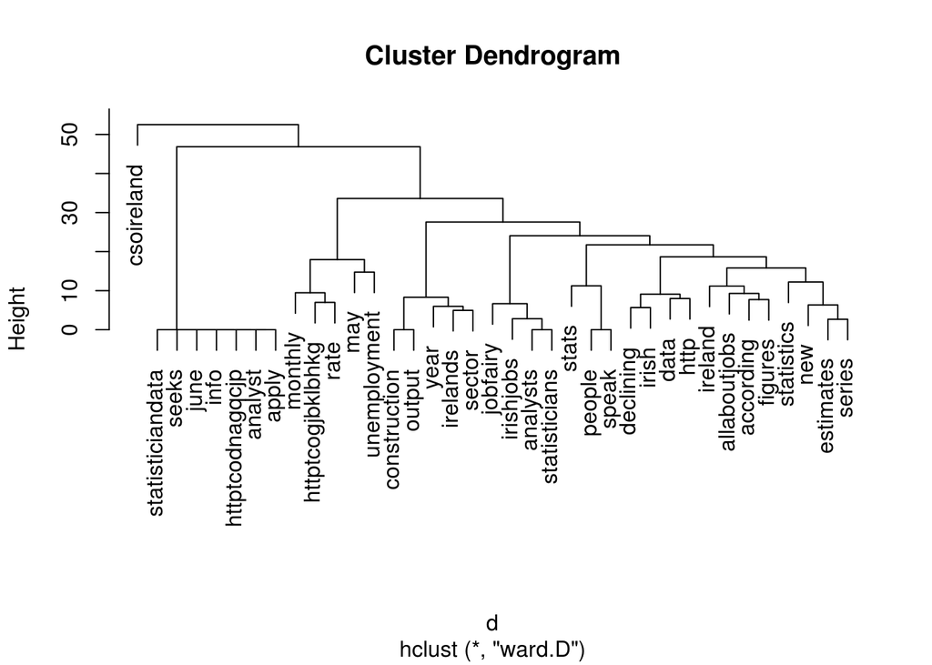

Terms higher in the plot appear more frequently within the body of tweets.

Terms grouped near to each other are more frequently found together.

Now we can build a network graph that represents the number of co-occurrences of two terms/words, i.e. a term and itself or another term.

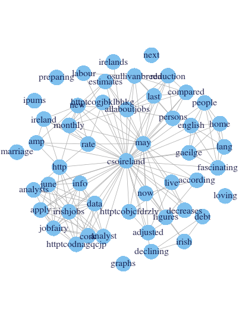

http://fredgibbs.net/tutorials/tutorial/document-similarity-with-r/

http://www.r-bloggers.com/an-example-of-social-network-analysis-with-r-using-package-igraph/

https://heuristically.wordpress.com/2011/04/08/text-data-mining-twitter-r/